# Reproducible Research: Peer Assessment 1

This report will analyze data recorded by a personal activity monitoring device. The code below assumes that the necessary data has already been downloaded and extracted into the working directory. If you do not already have a copy of the data, you can download it from:  
https://d396qusza40orc.cloudfront.net/repdata%2Fdata%2Factivity.zip

## Loading and preprocessing the data

To load the data, we can use the `read.csv` function. We’ll store the data in a data frame called `activity`.

```r
activity <- read.csv("activity.csv")
```

By default, R will read the `date` column as a factor instead of as a Date object. To make the data easier to process, we can convert it to a Date object like so:

```r
activity$date <- as.Date(activity$date, format="%Y-%m-%d")
```

Now that the data is loaded and formatted for use, we can begin our analysis.

## What is mean total number of steps taken per day?

For this part of the analysis, we will ignore any `NA` values. Our first task is to calculate the total number of steps taken per day. This is fairly straight-forward with the help of the `dplyr` package. We’ll store the daily summary in a new data frame called `totals`.

```r
library(dplyr)
totals <- group_by(activity, date) %>% summarise(steps = sum(steps, na.rm = TRUE))
```

To help us quickly visualize how many steps per day are being taken, we can make a simple histogram.

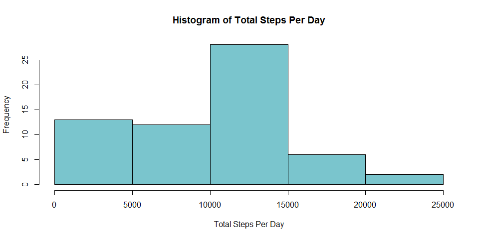

```r
hist(totals$steps,
     main="Histogram of Total Steps Per Day",
     xlab="Total Steps Per Day",
     c="cadetblue3")
```

Now we can answer the first question of our analysis: What is the mean total steps taken per day?

```r
mean(totals$steps)
```

```
## [1] 9354.23
```

And, just for the sake of completeness, we can also check the median total steps taken per day.

```r
median(totals$steps)
```

```
## [1] 10395
```

## What is the average daily activity pattern?

Next we’ll examine the daily activity pattern. For this, we want to compute the average number of steps taken within each 5-minute interval across all of the days in the data set.

Once again, this computation is fairly straight-forward using `dplyr`. As in the previous section, we’ll ignore any `NA` values.

```r
intervals <- group_by(activity, interval) %>% summarise(steps = mean(steps, na.rm = TRUE))
```

We’ll use a time-series plot to helps visualize this data.

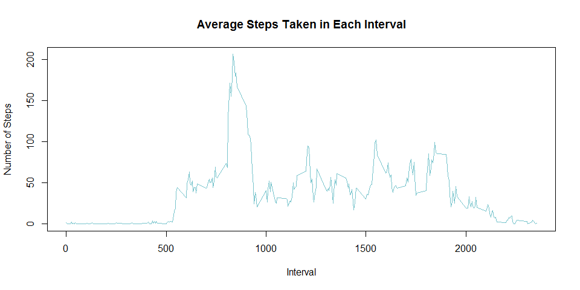

```r
plot(intervals$interval, intervals$steps,
     main="Average Steps Taken in Each Interval",
     xlab="Interval",
     ylab="Number of Steps",
     type="l",
     col="cadetblue3")
```

Which of the 5-minute intervals has the highest average number of steps?

```r
intervals[which(intervals$steps == max(intervals$steps)),]
```

```
## Source: local data frame [1 x 2]
##
##   interval    steps
## 1      835 206.1698
```

## Imputing missing values

So far in this analysis, we’ve been ignoring the `NA` values in the `steps` column. It’s possible that this could introduce bias into some of our calculations. So let’s first see how many `NA` values we’re dealing with.

```r
sum(is.na(activity$steps))
```

```
## [1] 2304
```

We’ll use a simple stategy to impute the missing values. We’ll replace all of the `NA` values with the average number of steps in that same interval across all of the days. However, we don’t want to overwrite our original data. Instead, we’ll make a copy of the original called `activity.imp` and use that copy to impute the missing values.

```r
activity.imp <- activity

getAverageStepsForInterval <- function(i) {
    intervals$steps[which(intervals$interval == i)]
}

activity.imp[which(is.na(activity.imp$steps)), 1] <-
    sapply(activity.imp[which(is.na(activity.imp$steps)),3], getAverageStepsForInterval)
```

Let’s be sure that our new data frame does not have any missing values.

```r
sum(is.na(activity.imp$steps))
```

```
## [1] 0
```

Looks like we were successful! So how do these imputed values affect our data set? Let’s run some of the same analysis we ran earlier our new data frame so we can compare. We’ll start by computing the total steps taken per day.

```r
totals.imp <- group_by(activity.imp, date) %>% summarise(steps = sum(steps))
```

Now let’s remake our histogram using the imputed values.

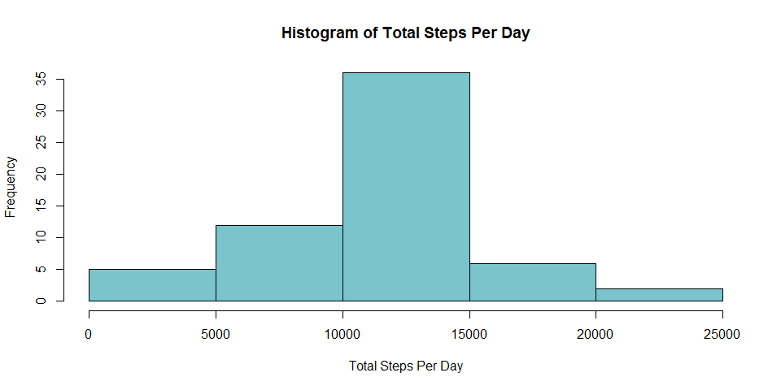

```r
hist(totals.imp$steps,
     main="Histogram of Total Steps Per Day",
     xlab="Total Steps Per Day",
     c="cadetblue3")
```

What is the mean total steps per day when using our imputed values?

```r
mean(totals.imp$steps)
```

```
## [1] 10766.19
```

What is the median total steps per day when using our imputed values?

```r
median(totals.imp$steps)
```

```
## [1] 10766.19
```

As expected, the imputed values have altered our computations. The mean increased by 1412 steps, which is an increase of 15.09%. The values in the histogram have clearly shifted towards the middle bin.

## Are there differences in activity patterns between weekdays and weekends?

For the final part of our analysis, we’ll compare the activity on weekdays to the activity on weekends. For this analysis, we’ll use the data frame that has filled in the missing values.

First, let’s augment our data frame with a factor column that tell us whether the day is a weekday or part of the weekend.

```r
activity.imp$weekday <-
    factor(ifelse(grepl("Saturday|Sunday", weekdays(activity.imp$date)), "weekend", "weekday"))
```

We will conclude with a panel plot with time series plots that compare the average steps in each interval between weekdays and weekends. First, we need to make a summary by weekday and interval based on our imputed values.

```r
intervals.imp <- group_by(activity.imp, weekday, interval) %>%
                 summarise(steps = mean(steps))
```

Now we can make our plot.

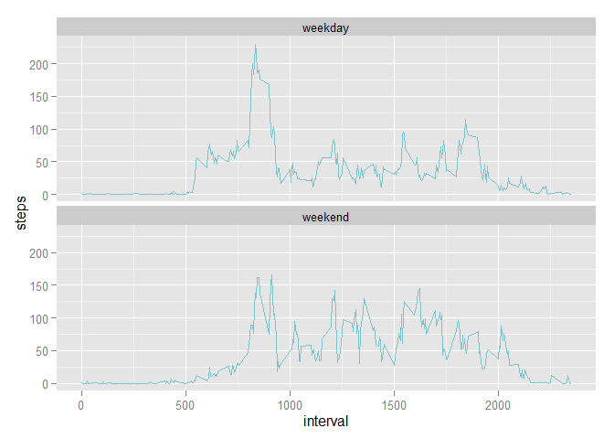

```r
library(ggplot2)
ggplot(intervals.imp, aes(x=interval, y=steps)) +
    geom_line(col="cadetblue3") +
    facet_wrap( ~ weekday, ncol=1)
```